# ASDA - Geostatistics Lecture 1: Demo

# General

## Install packages

If you have not done so already, install the required packages using

```r
geostat_pkgs <- c("sf", "sp", "geoR",  "gstat", "automap", "intamap", "tidyverse", "pacman", "tmap", "tmaptools", "spData",
                  "elevatr", "stars")
install.packages(geostat_pkgs )
remotes::install_github("wmgeolab/rgeoboundaries")
```

**(Only do this once)**

Get Help

`ls("package:sp")` `help(package = sp)`

## Load packages

Load packages

```r
pacman::p_load(skimr, sf, sp, gstat, stars, tidyverse,tmap, tmaptools, spData, rgdal, raster, maptools, GGally, rgeoboundaries, elevatr)
```

# Analysis Example - The meuse data

## Description

This data set gives locations and top soil heavy metal concentrations (ppm), along with a number of soil and landscape variables, collected in a flood plain of the river Meuse, near the village Stein. The data comes with the `sp` package in `R`.

### Plotting geometry

**Format**

This data frame contains the following columns:

- a numeric vector; x-coordinate (m) in RDM (Dutch topographical map coordinates)
- [y] a numeric vector; y-coordinate (m) in RDM (Dutch topographical map coordinates)
- [cadmium] topsoil cadmium concentration, ppm.; note that zero cadmium values in the original data set have been shifted to 0.2 (half the lowest non-zero value)
- [copper] topsoil copper concentration, ppm.
- [lead] topsoil lead concentration, ppm.
- [zinc] topsoil zinc concentration, ppm.
- [elev] relative elevation
- [dist] distance to river Meuse; obtained from the nearest cell in , which in turn was derived by a spread (spatial distance) GIS operation, therefore it is accurate up to 20 metres; normalized $[0,1]$
- [om] organic matter, as percentage
- [ffreq] flooding frequency class
- [soil] soil type
- [lime] lime class
- [landuse] landuse class
- [dist.m] distance to river Meuse (metres), as obtained during the field survey

References

- P.A. Burrough, R.A. McDonnell, 1998. Principles of Geographical Information Systems. Oxford University Press.
- (http:/www.gstat.org/)

## meuse.area

```r
data(meuse.area)  # A regular data frame
str(meuse.area)
```

```
 num [1:391, 1:2] 180640 180640 180600 180600 180560 ...
 - attr(*, "dimnames")=List of 2
  ..$ : NULL
  ..$ : chr [1:2] "x" "y"
```

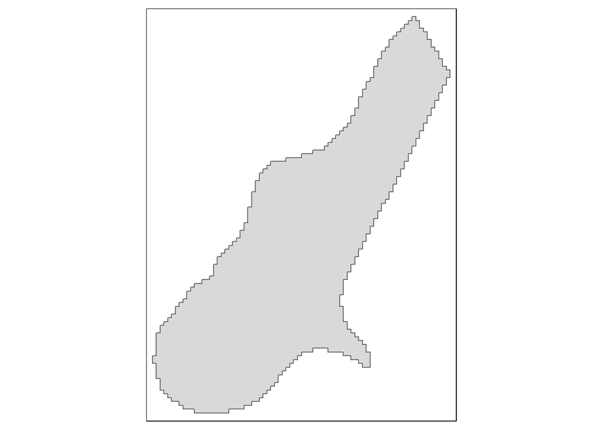

```r
meuse.area <- SpatialPolygons(list(Polygons(list(Polygon(meuse.area)),'1')))
proj4string(meuse.area)<- CRS("+init=epsg:28992")
# Plot of data
tm_shape(meuse.area) + tm_polygons()
```

## The data (meuse)

```r
# Read Data and convert to spatial data

data(meuse)
str(meuse) # A regular data frame
```

```
'data.frame':   155 obs. of  14 variables:
 $ x      : num  181072 181025 181165 181298 181307 ...
 $ y      : num  333611 333558 333537 333484 333330 ...
 $ cadmium: num  11.7 8.6 6.5 2.6 2.8 3 3.2 2.8 2.4 1.6 ...
 $ copper : num  85 81 68 81 48 61 31 29 37 24 ...
 $ lead   : num  299 277 199 116 117 137 132 150 133 80 ...
 $ zinc   : num  1022 1141 640 257 269 ...
 $ elev   : num  7.91 6.98 7.8 7.66 7.48 ...
 $ dist   : num  0.00136 0.01222 0.10303 0.19009 0.27709 ...
 $ om     : num  13.6 14 13 8 8.7 7.8 9.2 9.5 10.6 6.3 ...
 $ ffreq  : Factor w/ 3 levels "1","2","3": 1 1 1 1 1 1 1 1 1 1 ...
 $ soil   : Factor w/ 3 levels "1","2","3": 1 1 1 2 2 2 2 1 1 2 ...
 $ lime   : Factor w/ 2 levels "0","1": 2 2 2 1 1 1 1 1 1 1 ...
 $ landuse: Factor w/ 15 levels "Aa","Ab","Ag",..: 4 4 4 11 4 11 4 2 2 15 ...
 $ dist.m : num  50 30 150 270 380 470 240 120 240 420 ...
```

```r
coords <- SpatialPoints(meuse[, c("x", "y")])
meuse1 <- SpatialPointsDataFrame(coords, meuse)
summary(coords)
```

```
Object of class SpatialPoints
Coordinates:
     min    max
x 178605 181390
y 329714 333611
Is projected: NA
proj4string : [NA]
Number of points: 155
```

```r
coordinates(meuse) <- c("x", "y") # tells r to use x and y columns as the lat/long
proj4string(meuse) <- CRS("+init=epsg:28992") # Set projection
#meuse <- spTransform(meuse, CRS("+proj=longlat +datum=WGS84"))
str(meuse)
```

```
Formal class 'SpatialPointsDataFrame' [package "sp"] with 5 slots
  ..@ data       :'data.frame': 155 obs. of  12 variables:
  .. ..$ cadmium: num [1:155] 11.7 8.6 6.5 2.6 2.8 3 3.2 2.8 2.4 1.6 ...
  .. ..$ copper : num [1:155] 85 81 68 81 48 61 31 29 37 24 ...
  .. ..$ lead   : num [1:155] 299 277 199 116 117 137 132 150 133 80 ...
  .. ..$ zinc   : num [1:155] 1022 1141 640 257 269 ...
  .. ..$ elev   : num [1:155] 7.91 6.98 7.8 7.66 7.48 ...
  .. ..$ dist   : num [1:155] 0.00136 0.01222 0.10303 0.19009 0.27709 ...
  .. ..$ om     : num [1:155] 13.6 14 13 8 8.7 7.8 9.2 9.5 10.6 6.3 ...
  .. ..$ ffreq  : Factor w/ 3 levels "1","2","3": 1 1 1 1 1 1 1 1 1 1 ...
  .. ..$ soil   : Factor w/ 3 levels "1","2","3": 1 1 1 2 2 2 2 1 1 2 ...
  .. ..$ lime   : Factor w/ 2 levels "0","1": 2 2 2 1 1 1 1 1 1 1 ...
  .. ..$ landuse: Factor w/ 15 levels "Aa","Ab","Ag",..: 4 4 4 11 4 11 4 2 2 15 ...
  .. ..$ dist.m : num [1:155] 50 30 150 270 380 470 240 120 240 420 ...
  ..@ coords.nrs : int [1:2] 1 2
  ..@ coords     : num [1:155, 1:2] 181072 181025 181165 181298 181307 ...
  .. ..- attr(*, "dimnames")=List of 2
  .. .. ..$ : chr [1:155] "1" "2" "3" "4" ...
  .. .. ..$ : chr [1:2] "x" "y"
  ..@ bbox       : num [1:2, 1:2] 178605 329714 181390 333611
  .. ..- attr(*, "dimnames")=List of 2
  .. .. ..$ : chr [1:2] "x" "y"
  .. .. ..$ : chr [1:2] "min" "max"
  ..@ proj4string:Formal class 'CRS' [package "sp"] with 1 slot
  .. .. ..@ projargs: chr "+proj=sterea +lat_0=52.1561605555556 +lon_0=5.38763888888889 +k=0.9999079 +x_0=155000 +y_0=463000 +ellps=bessel"| __truncated__
  .. .. ..$ comment: chr "PROJCRS[\"Amersfoort / RD New\",\n    BASEGEOGCRS[\"Amersfoort\",\n        DATUM[\"Amersfoort\",\n            E"| __truncated__
```

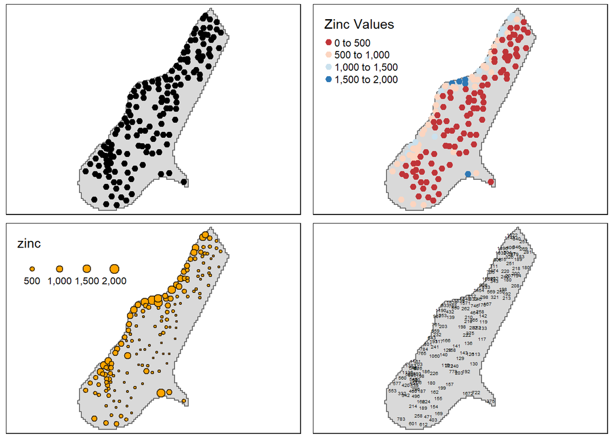

```r
# Plot Points
meuse_ptsa <- tm_shape(meuse.area) + tm_polygons() +
  tm_shape(meuse) +
  tm_dots(col = "black",
          title="Sampled locations", size=0.2)

meuse_ptsb <- tm_shape(meuse.area) + tm_polygons() +
  tm_shape(meuse) +
  tm_dots(col="zinc", palette = "RdBu", auto.palette.mapping = FALSE,
          title="Zinc Values", size=0.2) +
  tm_legend(legend.position=c("left","top"))

meuse_pts_bub <- tm_shape(meuse.area) + tm_polygons() +
  tm_shape(meuse) +
  tm_bubbles(size=c("zinc"),
             col=c("orange"),
             border.col="black",
             border.alpha = .75,
             scale=.7) +
  tm_legend(legend.position=c("left","top"))

# Plot Values
meuse_pts_vals <- tm_shape(meuse.area) + tm_polygons() +
  tm_shape(meuse) +
  tm_text("zinc", size = 0.3)

# Combine Plots
tmap_arrange(meuse_ptsa , meuse_ptsb , meuse_pts_bub , meuse_pts_vals)
```

## meuse.riv

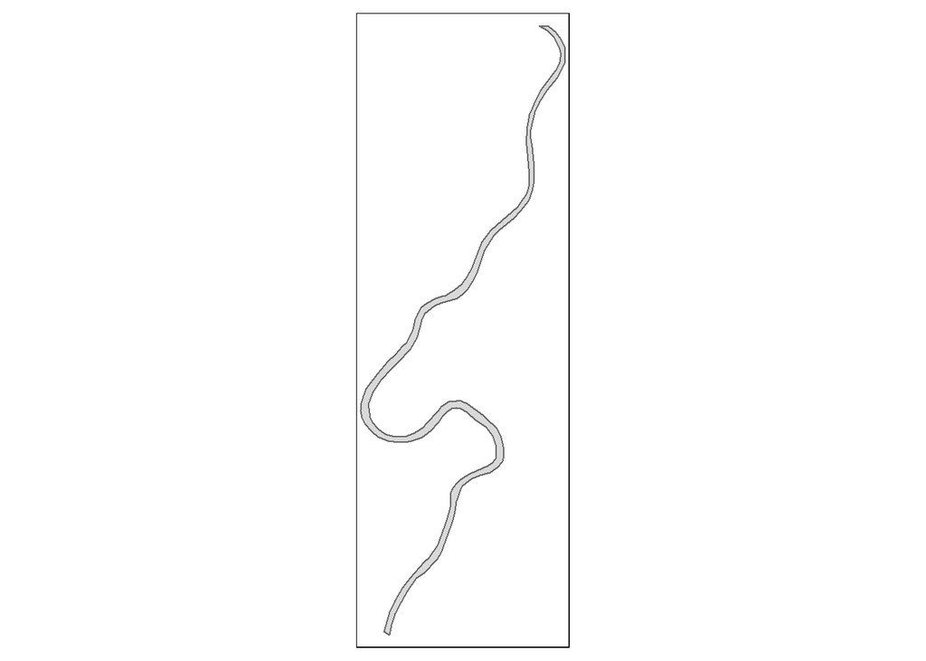

```r
data(meuse.riv)
meuse.riv.sp = SpatialPolygons(list(Polygons(list(Polygon(meuse.riv)),
    "meuse.riv")))
proj4string(meuse.riv.sp) <- CRS("+init=epsg:28992")
qtm(meuse.riv.sp)
```

```r
data(meuse.grid)
coords <- SpatialPixels(SpatialPoints(meuse.grid[,
    c("x", "y")]))
meuseg1 <- SpatialPixelsDataFrame(coords, meuse.grid)
```

# Plotting Extras

## Interactive maps

```r
tmap_mode("view")
```

```
tmap mode set to interactive viewing
```

```r
qtm(meuse)
```

[interactive chart not shown]

```r
tmap_mode("plot")
```

```
tmap mode set to plotting
```

## Plotting lines

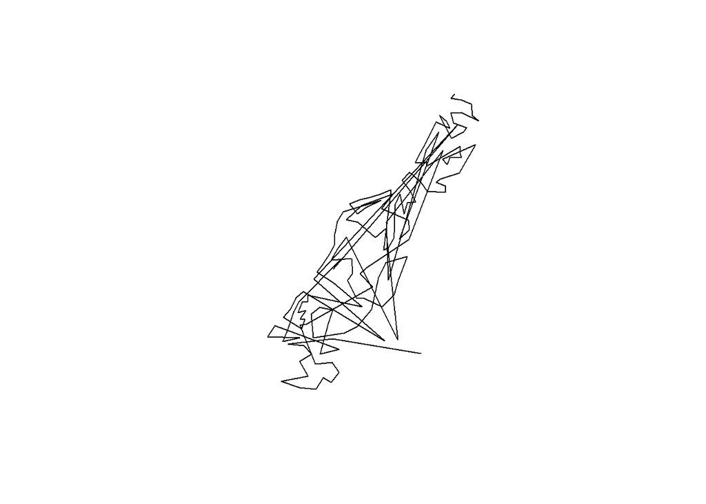

```r
cc <- coordinates(meuse)
m.sl <- SpatialLines(list(Lines(list(Line(cc)), "line1")))
proj4string(m.sl) <- CRS("+init=epsg:28992")
plot(m.sl) # plots lines connecting all the points
```

## Combining multiple elements

```r
tmap_mode("view")
```

```
tmap mode set to interactive viewing
```

```r
qtm(meuse) + qtm(m.sl) + qtm(meuse.riv.sp, fill="lightblue")
```

[interactive chart not shown]

```r
tmap_mode("plot")
```

```
tmap mode set to plotting
```

## Mapping a continous variable

Plot a continuous variable, using a particular class interval style.

See: [ArcGIS Data Classification Methods](https://pro.arcgis.com/en/pro-app/latest/help/mapping/layer-properties/data-classification-methods.htm)

```
Some legend labels were too wide. These labels have been resized to 0.65, 0.65. Increase legend.width (argument of tm_layout) to make the legend wider and therefore the labels larger.
Some legend labels were too wide. These labels have been resized to 0.65, 0.65. Increase legend.width (argument of tm_layout) to make the legend wider and therefore the labels larger.
```

```
Some legend labels were too wide. These labels have been resized to 0.65. Increase legend.width (argument of tm_layout) to make the legend wider and therefore the labels larger.
```

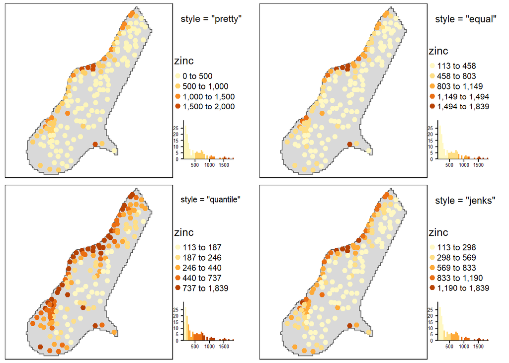

```r
m_zequal = tm_shape(meuse.area) + tm_polygons() +
  tm_shape(meuse) +
  tm_dots(col="zinc", style = "equal",  size=0.2, legend.hist = TRUE) +
  tm_layout(title = 'style = "equal"') +
  tm_legend(legend.position=c("right","bottom"), outside = TRUE, hist.width = 2)

m_zpretty = tm_shape(meuse.area) + tm_polygons() +
  tm_shape(meuse) +
  tm_dots(col="zinc", style = "pretty",  size=0.2, legend.hist = TRUE) +
  tm_layout(title = 'style = "pretty"')  +
  tm_legend(legend.position=c("right","bottom"), outside = TRUE, hist.width = 2)

m_zquantile = tm_shape(meuse.area) + tm_polygons() +
  tm_shape(meuse) +
  tm_dots(col="zinc", style = "quantile",  size=0.2, legend.hist = TRUE) +
  tm_layout(title = 'style = "quantile"')  +
  tm_legend(legend.position=c("right","bottom"), outside = TRUE, hist.width = 2)

m_zjenks = tm_shape(meuse.area) + tm_polygons() +
  tm_shape(meuse) +
  tm_dots(col="zinc", style = "jenks",  size=0.2, legend.hist = TRUE) +
  tm_layout(title = 'style = "jenks"')  +
  tm_legend(legend.position=c("right","bottom"), outside = TRUE, hist.width = 2)

tmap_arrange(m_zpretty, m_zequal, m_zquantile, m_zjenks)
```

## Colours

```
Listening on http://127.0.0.1:8210
```

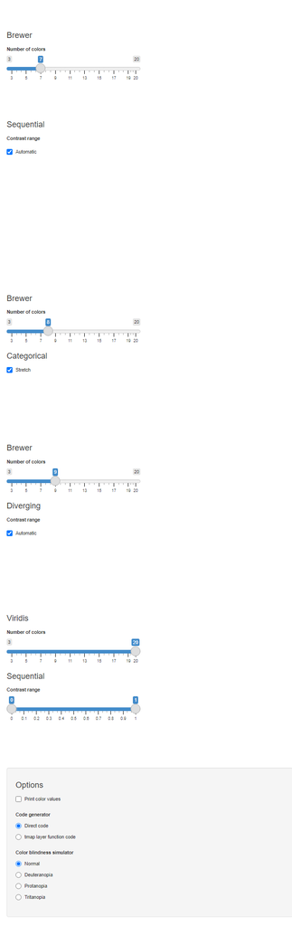

```r
tmaptools::palette_explorer()
```

# Sampling

## Learning Objectives:

TBC!

**Creating a Spatial Object**

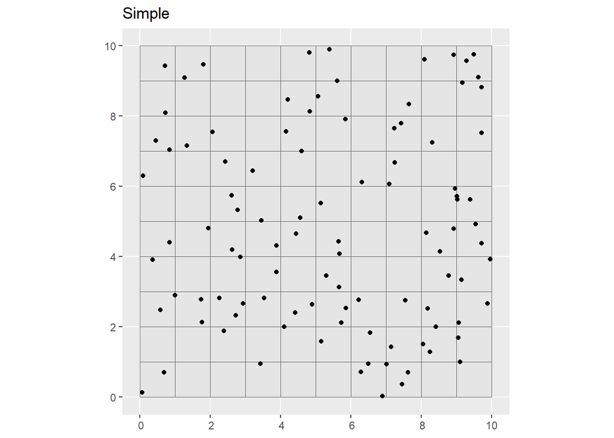

```r
library(sf)
library(ggplot2)

# set the seed for the random number generator
set.seed(4)

# Create a sixteen square polygon
bb <- st_make_grid(st_bbox(c(xmin = 0, xmax = 10, ymin = 0, ymax = 10)), n = 10)
grd <- st_as_sf(bb)
grd$ID <- 1:length(bb)



# Generate simple random sample
test <- st_sample(grd, size = 100, type = "random")

ggplot() +
  geom_sf(data = grd) +
  geom_sf(data = test) +
  ggtitle("Simple")
```

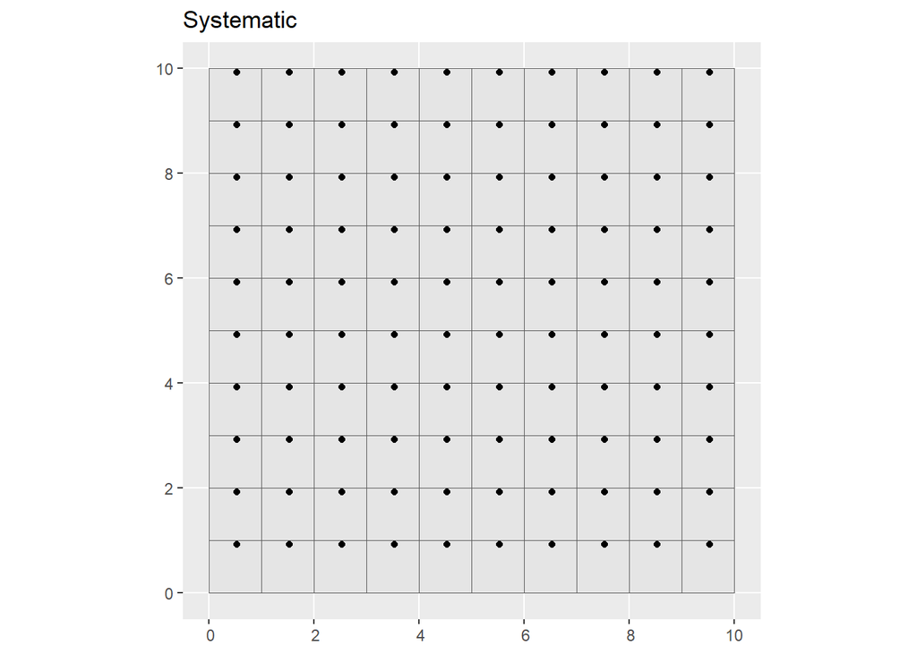

```r
# Generate systematic random sample
test <- st_sample(grd, size = 100, type = "regular")

ggplot() +
  geom_sf(data = grd) +
  geom_sf(data = test) +
  ggtitle("Systematic")
```

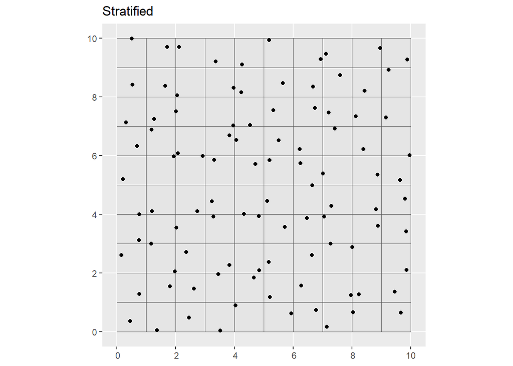

```r
# Generate stratified random sample
grd2 <- st_cast(grd, "MULTIPOLYGON")
st_crs(grd2) <- 5070

test <- st_sample(grd2, size = 100, type = "random", by_polygon = TRUE)

ggplot() +
  geom_sf(data = grd) +
  geom_sf(data = test) +
  ggtitle("Stratified")
```